# ML_lecture_note_03

### Logistic Regression (로지스틱 회귀)

```python
from IPython.display import Image
```

- 아래 그림의 (a)는 공부 시간과 점수를 측정한 산점도이다. 공부 시간이 증가할수록 점수가 선형적으로 증가하는 모습을 보인다. 반면, (b)의 경우는 일정 점수를 기준으로 '합격'과 '불합격'(합격 = 1, 불합격 = 0)으로 분리시킨 결과에 대한 산점도이다. 이는 직선보다 (b)에 그려진 'S자형' 곡선을 적용하는 경우 더욱 "잘" 설명하는 것처럼 보인다.

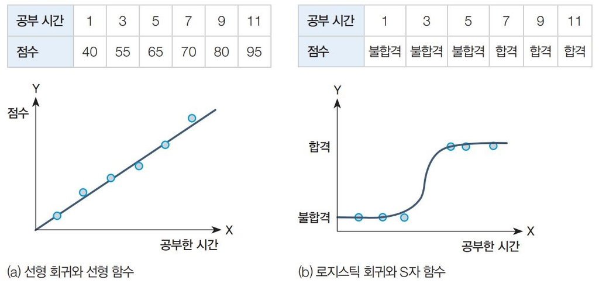

```python
Image('C:/Users/com/Desktop/ML/Lecture_03/Lecture_03_figure_01.jpg', width = 800, height = 400)
```

- 위의 '합격', '불합격'과 같이 결과가 두가지로 나오는 변수를 이진형(binary) 변수라고 한다. 암, 코로나 같은 병 진단(diagnosis)의 경우에도 결과를 '양성', '음성'과 같은 이진형 자료 형태로 나타난다.
- 이와같이 세부적인 수치(연속형)보다 합격/불합격 또는 양성/음성과 같이 판단 결과를 중요시 하는 경우 그 결과를 예측하기 위해 기존의 선형 회귀 방식을 적용하는데 무리가 있다. 즉, 그림 (b)와 같이 새로운 방식의 모형이 해당 자료를 "잘" 설명할 것으로 예상된다.

#### Odds (승산)

- 위 그림 (b)에서 합격에 대한 확률을 p라고 했을때 odds는 아래와 같이 표현된다.

$$ \begin{equation} Odds = \frac{p}{1-p} \ \ \ \ \ \ \ \ \ \ \ \ \ \ \ \ \ \ \ \ \ \ \ \ \ \ \ \ \ \ \ \ \end{equation} $$

- 식을 잘 살펴보면, 성공 확률(p)을 실패 확률(1 - p)로 나눈 표현임을 알 수 있다. 즉, odds란 성공 확률이 실패 확률보다 몇 배인지 판단할 수 있는 지표이다. 예를들어 성공 확률이 0.5 (p = 0.5)인 경우 실패 확률 역시 0.5 (1 - p = 1 - 0.5 = 0.5)로 odds는 1이 되며, 만약 성공 확률이 0.8 (p = 0.8)인 경우 실패 확률은 0.2 (1 - p = 1 - 0.8 = 0.2)로 odds는 4가 된다.
- odds를 이진형 변수를 예측하는 회귀 모형에 적용해보면 아래와 같다.

$$ \begin{equation} \frac{p}{1-p} = \beta_{0} + \beta_{1}x_{1} + \beta_{2}x_{2} + \cdots + \beta_{p}x_{p} + \epsilon \ \ \ \ \ \ \ \ \ \ \ \ \ \ \ \ \ \ \ \ \ \ \ \ \ \ \ \ \ \ \ \ \end{equation} $$

- 종속변수가 odds로 표현됨으로써 예측 결과가 odds값 1을 기준으로 1보다 크면 합격, 1보다 작으면 불합격의 형식으로 판단할 수 있을 것이다. 하지만 여기서 딱 한가지 아쉬운 점이 있다. 성공 확률 p는 확률값으로 0과 1 사이의 값으로 표현되므로 모형 좌측의 odds는 결국 0부터 $\infty$까지의 범위를 표현할 수 있는 반면, 우측의 선형 모형은 $-\infty$부터 $\infty$까지의 범위를 표현하기 때문에 좌변과 우변의 범위가 일치되지 않는 것이다.

#### Odds 범위의 확장 (로지스틱 회귀의 완성)

- 그렇다면 odds가 표현할 수 있는 범위를 $-\infty$까지 확장시킬 수 있는 모형이 있다면 위의 모형보다 더 적절할 것이다. 해결 방법은 간단하다. odds에 log를 취하는 것이다.

$$ \begin{equation} log\left(\frac{p}{1-p}\right) = \beta_{0} + \beta_{1}x_{1} + \beta_{2}x_{2} + \cdots + \beta_{p}x_{p} + \epsilon \ \ \ \ \ \ \ \ \ \ \ \ \ \ \ \ \ \ \ \ \ \ \ \ \ \ \ \ \ \ \ \ \end{equation} $$

- log함수는 0부터 $\infty$까지의 값을 정의역(진수)으로 사용하는 함수인데 odds가 표현할 수 있는 값이 딱 log함수의 정의역 범위와 일치한다. 또한 log함수의 치역은 $-\infty$부터 $\infty$까지 표현되어 우리가 원하는 $-\infty$까지 값이 확장될 수 있다.
- 위와같이 odds에 log를 취한 Log Odds를 종속변수로 활용한 모형을 로지스틱 회귀(Logistic Regression)이라고 한다.
- 로지스틱 회귀모형을 p에대해 정리해 아래와 같이 표현하면 이를 시그모이드(sigmoid) 함수라고 하며 이는 결국 우리가 찾던 S자 함수가 된다.

$$ \begin{equation} y = \frac{e^{\beta_{0} + \beta_{1}x_{1} + \beta_{2}x_{2} + \cdots + \beta_{p}x_{p} + \epsilon}}{1+e^{\beta_{0} + \beta_{1}x_{1} + \beta_{2}x_{2} + \cdots + \beta_{p}x_{p} + \epsilon}} \ \ \ or \ \ \ y = \frac{1}{1+e^{-(\beta_{0} + \beta_{1}x_{1} + \beta_{2}x_{2} + \cdots + \beta_{p}x_{p} + \epsilon)}}\ \ \ \ \ \ \ \ \ \ \ \ \ \ \ \ \ \ \ \ \ \ \ \ \ \ \ \ \ \ \ \ \end{equation} $$

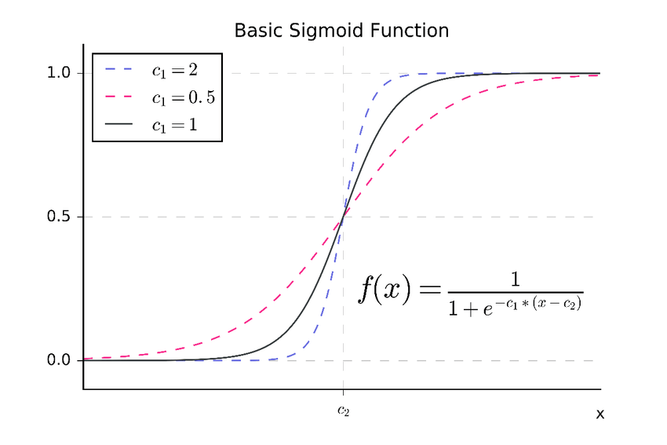

```python
Image('C:/Users/com/Desktop/ML/Lecture_03/Lecture_03_figure_02.jpg', width = 600, height = 300)
```

- 로지스틱 회귀에서 역시 $\beta$값을 추정해야 하는데 이때 최대 우도 추정법(Maximum liklihood estimation, MLE)을 사용하게 된다. 사실 앞서 선형 회귀에서 $\beta$값을 구할 때 OLS방법을 통해 설명했는데, 선형 회귀에서도 MLE 방식을 통해 $\beta$값을 구할 수 있다.(이는 수리통계학 수준의 내용을 다루므로 간단히 구두로 설명한다.) 단, 선형 회귀와 로지스틱 회귀 $\beta$값 추정에 있어 차이점은 선형 회귀는 $\beta$값에 대한 정확한 해(exact solution)가 존재하는 반면 로지스틱 회귀는 $\beta$ (beta)값에 대한 정확한 해를 찾을 수 없는 것이 차이점이다. 로지스틱 회귀에서는 이를 보안하기 위해 기울기 하강(Gradient Descent)과 같은 방법을 사용한다.(여기서는 아래 그림을 통해 간단히 설명하며, 더 자세한 내용은 '수치해석학' 과목을 통해 접할 수 있다.)

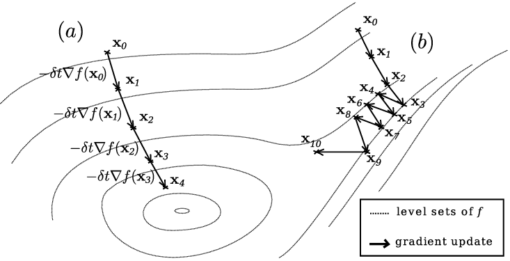

```python
Image('C:/Users/com/Desktop/ML/Lecture_03/Lecture_03_figure_03.jpg')
```

### Logistic Regression 실습 - Breast Cancer 데이터셋

#### [데이터 설명]

- 데이터: 위스콘신 유방암 진단 데이터
- 관측치 개수: 569개
- 변수 개수: 독립변수 30개 / 종속변수 1개

#### 독립변수 (세포 특징)

- radius : 반경 (중심에서 외벽까지 거리들의 평균값)
- texture : 질감 (Gray-Scale 값들의 표준편차)
- perimeter : 둘레
- area : 면적
- smoothness : 매끄러움 (반경길이의 국소적 벼노하)
- compactness : 조그만 정도 (둘레^2/면적-1)
- concavity : 오목함(윤관의 오목한 부분의 정도)
- concave points : 오목한 점의 수
- symmetry : 대칭
- fractal dimension : 프랙탈 차원 (해안선근사-1)

#### 종속변수 (양성 여부)

- malignant : 0, 악성 / Benign : 1, 양성

```python
import warnings
warnings.filterwarnings('ignore')
```

```python
import pandas as pd
import numpy as np
import matplotlib.pyplot as plt

# matplotlib 한글 문제
from matplotlib import font_manager, rc
font_name = font_manager.FontProperties(fname = "c:/Windows/Fonts/malgun.ttf").get_name()
rc('font', family = font_name)
```

```python
from sklearn.datasets import load_breast_cancer
breast_cancer = load_breast_cancer()
print(breast_cancer.DESCR)
```

```
.. _breast_cancer_dataset:

Breast cancer wisconsin (diagnostic) dataset
--------------------------------------------

**Data Set Characteristics:**

    :Number of Instances: 569

    :Number of Attributes: 30 numeric, predictive attributes and the class

    :Attribute Information:
        - radius (mean of distances from center to points on the perimeter)
        - texture (standard deviation of gray-scale values)
        - perimeter
        - area
        - smoothness (local variation in radius lengths)
        - compactness (perimeter^2 / area - 1.0)
        - concavity (severity of concave portions of the contour)
        - concave points (number of concave portions of the contour)
        - symmetry
        - fractal dimension ("coastline approximation" - 1)

        The mean, standard error, and "worst" or largest (mean of the three
        worst/largest values) of these features were computed for each image,
        resulting in 30 features.  For instance, field 0 is Mean Radius, field
        10 is Radius SE, field 20 is Worst Radius.

        - class:
                - WDBC-Malignant
                - WDBC-Benign

    :Summary Statistics:

    ===================================== ====== ======
                                           Min    Max
    ===================================== ====== ======
    radius (mean):                        6.981  28.11
    texture (mean):                       9.71   39.28
    perimeter (mean):                     43.79  188.5
```

[output cut: 63 more lines]

```
ftp ftp.cs.wisc.edu
cd math-prog/cpo-dataset/machine-learn/WDBC/

.. topic:: References

   - W.N. Street, W.H. Wolberg and O.L. Mangasarian. Nuclear feature extraction
     for breast tumor diagnosis. IS&T/SPIE 1993 International Symposium on
     Electronic Imaging: Science and Technology, volume 1905, pages 861-870,
     San Jose, CA, 1993.
   - O.L. Mangasarian, W.N. Street and W.H. Wolberg. Breast cancer diagnosis and
     prognosis via linear programming. Operations Research, 43(4), pages 570-577,
     July-August 1995.
   - W.H. Wolberg, W.N. Street, and O.L. Mangasarian. Machine learning techniques
     to diagnose breast cancer from fine-needle aspirates. Cancer Letters 77 (1994)
     163-171.
```

```python
# 독립변수와 종속변수 분리
X = pd.DataFrame(breast_cancer.data, columns=breast_cancer.feature_names)
Y = pd.DataFrame(breast_cancer.target, columns=['target'])
```

```python
X.head()
```

|  | mean radius | mean texture | mean perimeter | mean area | mean smoothness | mean compactness | mean concavity | mean concave points | mean symmetry | mean fractal dimension | ... | worst radius | worst texture | worst perimeter | worst area | worst smoothness | worst compactness | worst concavity | worst concave points | worst symmetry | worst fractal dimension |
| --- | --- | --- | --- | --- | --- | --- | --- | --- | --- | --- | --- | --- | --- | --- | --- | --- | --- | --- | --- | --- | --- |
| 0 | 17.99 | 10.38 | 122.80 | 1001.0 | 0.11840 | 0.27760 | 0.3001 | 0.14710 | 0.2419 | 0.07871 | ... | 25.38 | 17.33 | 184.60 | 2019.0 | 0.1622 | 0.6656 | 0.7119 | 0.2654 | 0.4601 | 0.11890 |
| 1 | 20.57 | 17.77 | 132.90 | 1326.0 | 0.08474 | 0.07864 | 0.0869 | 0.07017 | 0.1812 | 0.05667 | ... | 24.99 | 23.41 | 158.80 | 1956.0 | 0.1238 | 0.1866 | 0.2416 | 0.1860 | 0.2750 | 0.08902 |
| 2 | 19.69 | 21.25 | 130.00 | 1203.0 | 0.10960 | 0.15990 | 0.1974 | 0.12790 | 0.2069 | 0.05999 | ... | 23.57 | 25.53 | 152.50 | 1709.0 | 0.1444 | 0.4245 | 0.4504 | 0.2430 | 0.3613 | 0.08758 |
| 3 | 11.42 | 20.38 | 77.58 | 386.1 | 0.14250 | 0.28390 | 0.2414 | 0.10520 | 0.2597 | 0.09744 | ... | 14.91 | 26.50 | 98.87 | 567.7 | 0.2098 | 0.8663 | 0.6869 | 0.2575 | 0.6638 | 0.17300 |
| 4 | 20.29 | 14.34 | 135.10 | 1297.0 | 0.10030 | 0.13280 | 0.1980 | 0.10430 | 0.1809 | 0.05883 | ... | 22.54 | 16.67 | 152.20 | 1575.0 | 0.1374 | 0.2050 | 0.4000 | 0.1625 | 0.2364 | 0.07678 |

5 rows × 30 columns

```python
X.shape
```

```
(569, 30)
```

```python
import statsmodels.api as sm
```

```python
# intercept 추가
X = sm.add_constant(X, has_constant='add')
```

```python
X.head()
```

|  | const | mean radius | mean texture | mean perimeter | mean area | mean smoothness | mean compactness | mean concavity | mean concave points | mean symmetry | ... | worst radius | worst texture | worst perimeter | worst area | worst smoothness | worst compactness | worst concavity | worst concave points | worst symmetry | worst fractal dimension |
| --- | --- | --- | --- | --- | --- | --- | --- | --- | --- | --- | --- | --- | --- | --- | --- | --- | --- | --- | --- | --- | --- |
| 0 | 1.0 | 17.99 | 10.38 | 122.80 | 1001.0 | 0.11840 | 0.27760 | 0.3001 | 0.14710 | 0.2419 | ... | 25.38 | 17.33 | 184.60 | 2019.0 | 0.1622 | 0.6656 | 0.7119 | 0.2654 | 0.4601 | 0.11890 |
| 1 | 1.0 | 20.57 | 17.77 | 132.90 | 1326.0 | 0.08474 | 0.07864 | 0.0869 | 0.07017 | 0.1812 | ... | 24.99 | 23.41 | 158.80 | 1956.0 | 0.1238 | 0.1866 | 0.2416 | 0.1860 | 0.2750 | 0.08902 |
| 2 | 1.0 | 19.69 | 21.25 | 130.00 | 1203.0 | 0.10960 | 0.15990 | 0.1974 | 0.12790 | 0.2069 | ... | 23.57 | 25.53 | 152.50 | 1709.0 | 0.1444 | 0.4245 | 0.4504 | 0.2430 | 0.3613 | 0.08758 |
| 3 | 1.0 | 11.42 | 20.38 | 77.58 | 386.1 | 0.14250 | 0.28390 | 0.2414 | 0.10520 | 0.2597 | ... | 14.91 | 26.50 | 98.87 | 567.7 | 0.2098 | 0.8663 | 0.6869 | 0.2575 | 0.6638 | 0.17300 |
| 4 | 1.0 | 20.29 | 14.34 | 135.10 | 1297.0 | 0.10030 | 0.13280 | 0.1980 | 0.10430 | 0.1809 | ... | 22.54 | 16.67 | 152.20 | 1575.0 | 0.1374 | 0.2050 | 0.4000 | 0.1625 | 0.2364 | 0.07678 |

5 rows × 31 columns

```python
Y.tail()
```

|  | target |
| --- | --- |
| 564 | 0 |
| 565 | 0 |
| 566 | 0 |
| 567 | 0 |
| 568 | 1 |

```python
Y.shape
```

```
(569, 1)
```

```python
from sklearn.model_selection import train_test_split
```

```python
# 학습 데이터, 테스트 데이터 분리
X_train, X_test, Y_train, Y_test = train_test_split(X, Y, train_size=0.7, test_size=0.3, random_state=1234, stratify=Y)
print(X_train.shape, X_test.shape, Y_train.shape, Y_test.shape)
```

```
(398, 31) (171, 31) (398, 1) (171, 1)
```

```python
# 로지스틱 회귀 모델 생성
logit_m = sm.Logit(Y_train, X_train)
logit_m_train = logit_m.fit(method='powell') # powell, cg, bfgs, lbfgs
```

```python
logit_m_train.summary()
```

Logit Regression Results

| Dep. Variable: | target | No. Observations: | 398 |
| --- | --- | --- | --- |
| Model: | Logit | Df Residuals: | 367 |
| Method: | MLE | Df Model: | 30 |
| Date: | Fri, 24 Sep 2021 | Pseudo R-squ.: | 0.9327 |
| Time: | 05:14:53 | Log-Likelihood: | -17.677 |
| converged: | False | LL-Null: | -262.66 |
| Covariance Type: | nonrobust | LLR p-value: | 1.381e-84 |

|  | coef | std err | z | P>\|z\| | [0.025 | 0.975] |
| --- | --- | --- | --- | --- | --- | --- |
| const | 7.7081 | 54.480 | 0.141 | 0.887 | -99.071 | 114.487 |
| mean radius | 0.7912 | 18.273 | 0.043 | 0.965 | -35.023 | 36.606 |
| mean texture | 0.0261 | 0.487 | 0.054 | 0.957 | -0.929 | 0.981 |
| mean perimeter | 0.1990 | 2.787 | 0.071 | 0.943 | -5.264 | 5.662 |
| mean area | 0.0004 | 0.085 | 0.005 | 0.996 | -0.167 | 0.167 |
| mean smoothness | -127.5250 | 211.596 | -0.603 | 0.547 | -542.245 | 287.195 |
| mean compactness | 76.8910 | 143.641 | 0.535 | 0.592 | -204.639 | 358.421 |
| mean concavity | -93.5032 | 113.479 | -0.824 | 0.410 | -315.918 | 128.912 |
| mean concave points | -108.9617 | 187.019 | -0.583 | 0.560 | -475.511 | 257.588 |
| mean symmetry | -22.6477 | 62.936 | -0.360 | 0.719 | -146.000 | 100.704 |
| mean fractal dimension | 177.7199 | 524.466 | 0.339 | 0.735 | -850.215 | 1205.655 |
| radius error | 26.4757 | 83.270 | 0.318 | 0.751 | -136.730 | 189.682 |
| texture error | 2.1404 | 3.416 | 0.627 | 0.531 | -4.555 | 8.835 |
| perimeter error | -0.1968 | 5.863 | -0.034 | 0.973 | -11.688 | 11.295 |
| area error | -0.5250 | 0.727 | -0.722 | 0.470 | -1.950 | 0.900 |
| smoothness error | -427.0441 | 679.255 | -0.629 | 0.530 | -1758.359 | 904.271 |
| compactness error | 110.0794 | 327.673 | 0.336 | 0.737 | -532.149 | 752.307 |
| concavity error | 20.3282 | 133.504 | 0.152 | 0.879 | -241.334 | 281.990 |
| concave points error | 335.9700 | 875.071 | 0.384 | 0.701 | -1379.139 | 2051.079 |
| symmetry error | 198.5205 | 391.924 | 0.507 | 0.612 | -569.636 | 966.677 |
| fractal dimension error | 160.5365 | 1817.119 | 0.088 | 0.930 | -3400.952 | 3722.025 |
| worst radius | -0.5519 | 8.038 | -0.069 | 0.945 | -16.305 | 15.202 |
| worst texture | -0.5303 | 0.470 | -1.127 | 0.260 | -1.452 | 0.392 |
| worst perimeter | 0.1487 | 0.837 | 0.178 | 0.859 | -1.492 | 1.789 |
| worst area | -0.0181 | 0.075 | -0.242 | 0.809 | -0.165 | 0.129 |
| worst smoothness | 50.2341 | 113.484 | 0.443 | 0.658 | -172.191 | 272.659 |
| worst compactness | -16.2358 | 59.278 | -0.274 | 0.784 | -132.418 | 99.946 |
| worst concavity | 1.4300 | 23.167 | 0.062 | 0.951 | -43.976 | 46.836 |
| worst concave points | -48.0260 | 104.262 | -0.461 | 0.645 | -252.375 | 156.323 |
| worst symmetry | -9.1960 | 56.139 | -0.164 | 0.870 | -119.226 | 100.834 |
| worst fractal dimension | -54.2219 | 250.897 | -0.216 | 0.829 | -545.971 | 437.527 |

Possibly complete quasi-separation: A fraction 0.66 of observations can be  
perfectly predicted. This might indicate that there is complete  
quasi-separation. In this case some parameters will not be identified.

```python
Y_predict = logit_m_train.predict(X_test)
print(Y_predict)
```

```
61     9.999999e-01
114    9.999604e-01
489    9.558832e-01
161    9.994769e-13
128    9.961621e-01
           ...
142    9.999985e-01
356    9.999531e-01
392    3.614221e-15
464    9.957482e-01
41     2.391947e-04
Length: 171, dtype: float64
```

```python
from sklearn import metrics
from sklearn.metrics import confusion_matrix, accuracy_score, precision_score, recall_score, f1_score
```

```python
# 오차행렬(confusion matirx)를 통해 예측 성능 확인
confusion_matrix(Y_test, Y_predict)
```

```
---------------------------------------------------------------------------
ValueError                                Traceback (most recent call last)
<ipython-input-22-702aaf1a69f3> in <module>
      1 # 오차행렬(confusion matirx)를 통해 예측 성능 확인
----> 2 confusion_matrix(Y_test, Y_predict)

~\anaconda3\lib\site-packages\sklearn\utils\validation.py in inner_f(*args, **kwargs)
     70                           FutureWarning)
     71         kwargs.update({k: arg for k, arg in zip(sig.parameters, args)})
---> 72         return f(**kwargs)
     73     return inner_f
     74

~\anaconda3\lib\site-packages\sklearn\metrics\_classification.py in confusion_matrix(y_true, y_pred, labels, sample_weight, normalize)
    274
    275     """
--> 276     y_type, y_true, y_pred = _check_targets(y_true, y_pred)
    277     if y_type not in ("binary", "multiclass"):
    278         raise ValueError("%s is not supported" % y_type)

~\anaconda3\lib\site-packages\sklearn\metrics\_classification.py in _check_targets(y_true, y_pred)
     88
     89     if len(y_type) > 1:
---> 90         raise ValueError("Classification metrics can't handle a mix of {0} "
     91                          "and {1} targets".format(type_true, type_pred))
     92

ValueError: Classification metrics can't handle a mix of binary and continuous targets
```

- 오류가 발생한다. 무엇이 문제일까? 실제 종속변수의 값(Y_test)은 0, 1로 이루어진 반면 예측된 종속변수의 값(Y_predict)은 0.97, 0.52, 0.04과 같은 0과 1에 사이의 값들로 되어있다. 즉, 각 관측대상의 예측이 확률로 되어있는 것이다.(연속형) 이를 0과 1로 판단해 나눠줘야 하는데 이 때 기준값을 주어야 하며 이를 threshold라고 한다.

```python
# Y_predict를 threshold를 기준으로 0과 1로 나누어주는 함수 생성
def cut_off(y,threshold):
    Y = y.copy() # copy함수를 사용하여 이전의 y값이 변화지 않게 함
    Y[Y>threshold]=1
    Y[Y<=threshold]=0
    return(Y.astype(int))
```

```python
Y_predict_t = cut_off(Y_predict,0.5)
Y_predict_t.head()
```

```
61     1
114    1
489    1
161    0
128    1
dtype: int32
```

```python
# 오차행렬(confusion matirx)를 통해 예측 성능 확인
confusion_matrix(Y_test, Y_predict_t)
```

```
array([[ 62,   2],
       [  2, 105]], dtype=int64)
```

```python
accuracy = accuracy_score(Y_test, Y_predict_t)
precision = precision_score(Y_test, Y_predict_t)
recall = recall_score(Y_test, Y_predict_t)
f1 = f1_score(Y_test, Y_predict_t)
print('Accuracy : {0:.3f}'.format(accuracy))
print('Precision : {0:.3f}'.format(precision))
print('Recall : {0:.3f}'.format(recall))
print('F1 : {0:.3f}'.format(f1))
```

```
Accuracy : 0.977
Precision : 0.981
Recall : 0.981
F1 : 0.981
```

- 근데 과연 threshold를 0.5로 놓는것이 타당한가? 0~1 사이의 값의 변화를 줄때 성능이 어떻게 바뀌는지 확인해보자.

```python
# 임계값에 따른 비교
def perf_eval(cm):
    # Accuracy
    Accuracy = (cm[0, 0] + cm[1, 1]) / sum(cm.reshape(-1, ))
    # Precision
    Precision = cm[1, 1] /sum(cm[:, 1])
    # Recall
    Recall = cm[1, 1] / sum(cm[1])
    # F1-score
    F1 = 2 * Recall * Precision / (Recall + Precision)
    return ([Accuracy, Precision, Recall, F1])

threshold = np.arange(0,1,0.1)
table = pd.DataFrame(columns=['Accuracy','Precision','Recall','F1'])
for i in threshold:
    Y_predict_temp = cut_off(Y_predict,i)
    confusion_matrix_temp = confusion_matrix(Y_test, Y_predict_temp)
    table.loc[i] = perf_eval(confusion_matrix_temp)
table.index.name='threshold'
table.columns.name='performance'
print(table)
```

```
performance  Accuracy  Precision    Recall        F1
threshold
0.0          0.625731   0.625731  1.000000  0.769784
0.1          0.964912   0.954955  0.990654  0.972477
0.2          0.970760   0.963636  0.990654  0.976959
0.3          0.970760   0.972222  0.981308  0.976744
0.4          0.976608   0.981308  0.981308  0.981308
0.5          0.976608   0.981308  0.981308  0.981308
0.6          0.976608   0.981308  0.981308  0.981308
0.7          0.970760   0.981132  0.971963  0.976526
0.8          0.970760   0.981132  0.971963  0.976526
0.9          0.953216   0.980583  0.943925  0.961905
```

#### 성능평가지표 - ROC Curve & AUC

```python
Image('C:/Users/com/Desktop/ML/Lecture_03/Lecture_03_figure_04.jpg')
```

[output not shown]

```python
from sklearn.metrics import accuracy_score, roc_auc_score, roc_curve
```

```python
def plot_ROC(y_train_true, y_train_prob, y_test_true, y_test_prob):
    '''
    a funciton to plot the ROC curve for train labels and test labels.
    Use the best threshold found in train set to classify items in test set.
    '''
    fpr_train, tpr_train, thresholds_train = roc_curve(y_train_true, y_train_prob, pos_label =True)
    sum_sensitivity_specificity_train = tpr_train + (1-fpr_train)
    best_threshold_id_train = np.argmax(sum_sensitivity_specificity_train)
    best_threshold = thresholds_train[best_threshold_id_train]
    best_fpr_train = fpr_train[best_threshold_id_train]
    best_tpr_train = tpr_train[best_threshold_id_train]
    y_train = y_train_prob > best_threshold

    cm_train = confusion_matrix(y_train_true, y_train)
    acc_train = accuracy_score(y_train_true, y_train)
    auc_train = roc_auc_score(y_train_true, y_train)

    print('Train Accuracy: %s ' %acc_train)
    print('Train AUC: %s ' %auc_train)
    print('Train Confusion Matrix:')
    print(cm_train)

    fig = plt.figure(figsize=(10,5))
    ax = fig.add_subplot(121)
    curve1 = ax.plot(fpr_train, tpr_train)
    curve2 = ax.plot([0, 1], [0, 1], color='navy', linestyle='--')
    dot = ax.plot(best_fpr_train, best_tpr_train, marker='o', color='black')
    ax.text(best_fpr_train, best_tpr_train, s = '(%.3f,%.3f)' %(best_fpr_train, best_tpr_train))
    plt.xlim([0.0, 1.0])
    plt.ylim([0.0, 1.0])
    plt.xlabel('False Positive Rate')
    plt.ylabel('True Positive Rate')
    plt.title('ROC curve (Train), AUC = %.4f'%auc_train)

    fpr_test, tpr_test, thresholds_test = roc_curve(y_test_true, y_test_prob, pos_label =True)

    y_test = y_test_prob > best_threshold

    cm_test = confusion_matrix(y_test_true, y_test)
    acc_test = accuracy_score(y_test_true, y_test)
    auc_test = roc_auc_score(y_test_true, y_test)

    print('Test Accuracy: %s ' %acc_test)
    print('Test AUC: %s ' %auc_test)
    print('Test Confusion Matrix:')
    print(cm_test)

    tpr_score = float(cm_test[1][1])/(cm_test[1][1] + cm_test[1][0])
    fpr_score = float(cm_test[0][1])/(cm_test[0][0]+ cm_test[0][1])

    ax2 = fig.add_subplot(122)
    curve1 = ax2.plot(fpr_test, tpr_test)
    curve2 = ax2.plot([0, 1], [0, 1], color='navy', linestyle='--')
    dot = ax2.plot(fpr_score, tpr_score, marker='o', color='black')
    ax2.text(fpr_score, tpr_score, s = '(%.3f,%.3f)' %(fpr_score, tpr_score))
    plt.xlim([0.0, 1.0])
    plt.ylim([0.0, 1.0])
    plt.xlabel('False Positive Rate')
    plt.ylabel('True Positive Rate')
    plt.title('ROC curve (Test), AUC = %.4f'%auc_test)
    plt.savefig('ROC', dpi = 500)
    plt.show()

    return best_threshold
```

```
Train Accuracy: 0.9849246231155779
Train AUC: 0.9838648648648649
Train Confusion Matrix:
[[145   3]
 [  3 247]]
Test Accuracy: 0.9707602339181286
Test AUC: 0.970356308411215
Test Confusion Matrix:
[[ 62   2]
 [  3 104]]
```

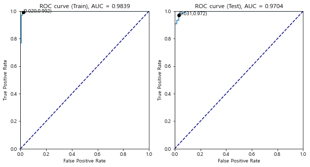

```
Best Threshold: 0.6238656740844232
```

```python
best_threshold = plot_ROC(y_train_true=Y_train, y_train_prob=logit_m_train.predict(X_train),
                          y_test_true=Y_test, y_test_prob=logit_m_train.predict(X_test))
print('Best Threshold:', best_threshold)
```

- 그렇다면 로지스틱과 KNN을 비교하면 어떤 방법이 성능이 더 좋을까?